# SeqAn Usage Statistics

ZIP

## Timeframe

| What | Date |
| --- | --- |
| From | 2020-02-23 |
| To | 2025-01-25 |
| Today | 2026-11-05 |

The timeframe spans 257 weeks and 0 days.  
This is equivalent to 1,799 days or 257.00 weeks.

## The Data

The collected information contains the following columns:

| ID | Name | Description |
| --- | --- | --- |
| 1 | app | Application name |
| 2 | ip | IP address |
| 3 | calls | Number of calls |
| 4 | date | Date of the call |
| 5 | version | Application version |
| 6 | cpu | CPU-Mode (32/64-bit) |
| 7 | os | The operating system |
| 8 | who | How the call was sent (e.g., library, KNIME) |
| 9 | clustered | Call originates from known cluster |
| 10 | country_code | Country code¹ |
| 11 | country | Country¹ |
| 12 | region | Region¹ |
| 13 | city | City¹ |
| 14 | longitude | Longitude¹ |
| 15 | latitude | Latidude¹ |
| 16 | DevelopedBy | Tooltag (de.NBI, extern) |

¹ Derived from IP

## Citations

The number of citations of a set of important [selected publications](https://scholar.google.de/citations?hl=de&user=JWLBQHwAAAAJ) about or using SeqAn:

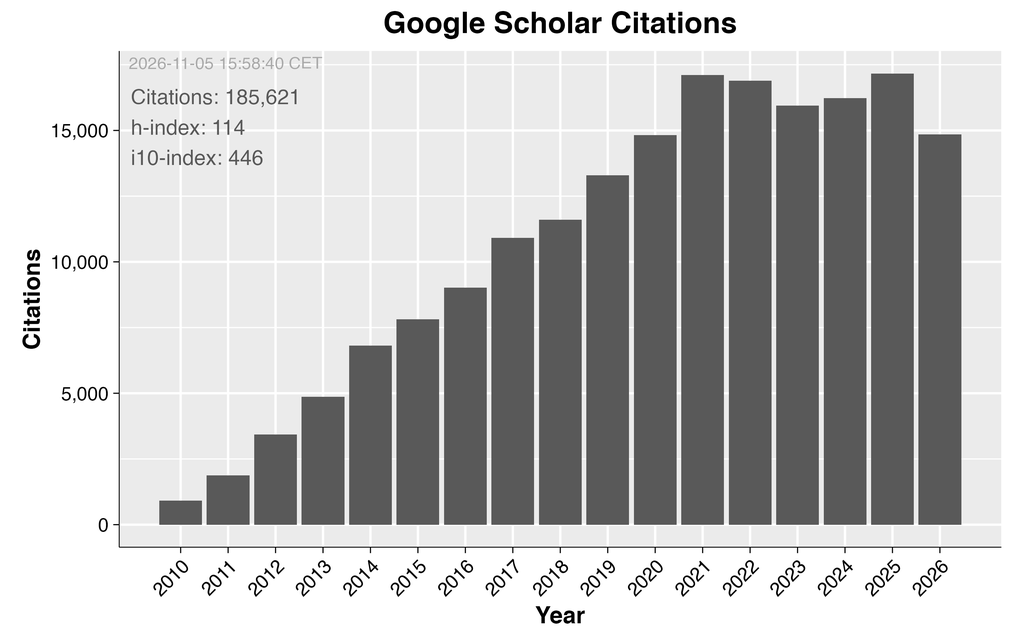

PDF PNG TSV

## Downloads

### Libraries

| Start | End | GitHub Downloads | Conda Downloads | PyPI Downloads | Total Downloads |
| --- | --- | --- | --- | --- | --- |
| 2025 Q1 | 2025 Q4 | 943.0 | 19593.0 | 0.0 | 20536.0 |
| 2025 Q4 | 2026 Q3 | 7918.0 | 16309.0 | 0.0 | 24227.0 |
| 2026 Q1 | 2026 Q4 | 7984.0 | 11258.0 | 0.0 | 19242.0 |

TSV

### Apps

| Start | End | GitHub Downloads | Conda Downloads | PyPI Downloads | Total Downloads |
| --- | --- | --- | --- | --- | --- |
| 2025 Q1 | 2025 Q4 | 6.0 | 161128.0 | 0.0 | 161134.0 |
| 2025 Q4 | 2026 Q3 | 0.0 | 97116.0 | 0.0 | 97116.0 |
| 2026 Q1 | 2026 Q4 | 0.0 | 58988.0 | 0.0 | 58988.0 |

TSV

## GitHub Issues and PR

| Start | End | Issues Opened | Issues Closed | PRs Opened | PRs Closed |
| --- | --- | --- | --- | --- | --- |
| 2025 Q1 | 2025 Q4 | 19.0 | 18.0 | 636.0 | 623.0 |
| 2025 Q4 | 2026 Q3 | 12.0 | 10.0 | 499.0 | 504.0 |
| 2026 Q1 | 2026 Q4 | 12.0 | 11.0 | 416.0 | 413.0 |

TSV

## General Usage

To display the general usage, the plot shows the cumulative usage of all application summed together over the given time period.

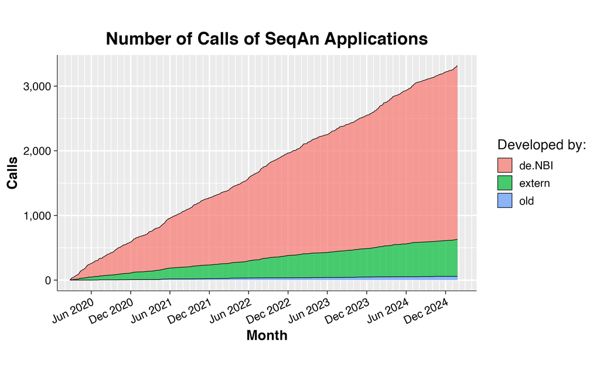

PDF PNG TSV

## Worldmap

[interactive chart not shown]

## Top 10 Applications

In the following the data was aggregated by application. The first figure pictures the sum of all calls of each application, while the second shows the number of unique users. The figures differentiate between individual and cluster calls/users. The term ‘cluster calls/users’ refers to IP addresses that were previously identified as part of a cluster, but left in the dataset as a representative for the corresponding cluster.

### By Calls

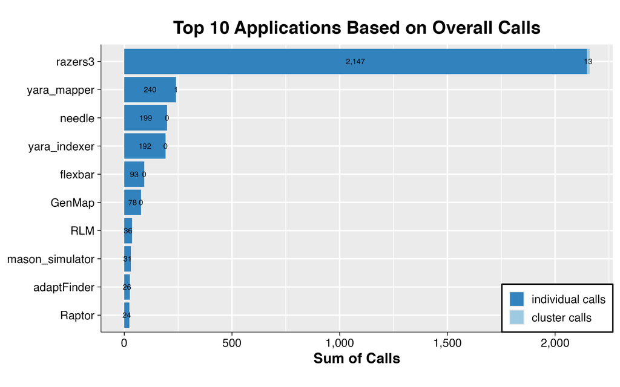

PDF PNG TSV

### By Users

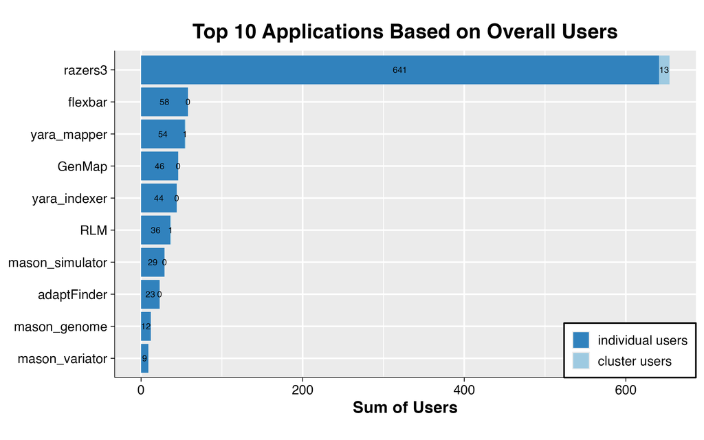

PDF PNG TSV

## Operating System

For an overview over the distribution of different operating systems the data was aggregated by column ‘os’. As before, the first figure pictures the sum of all calls of each operating system, while the second shows the number of unique users.

### By Calls

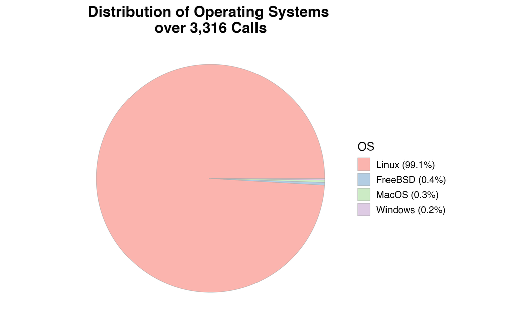

PDF PNG TSV

### By Users

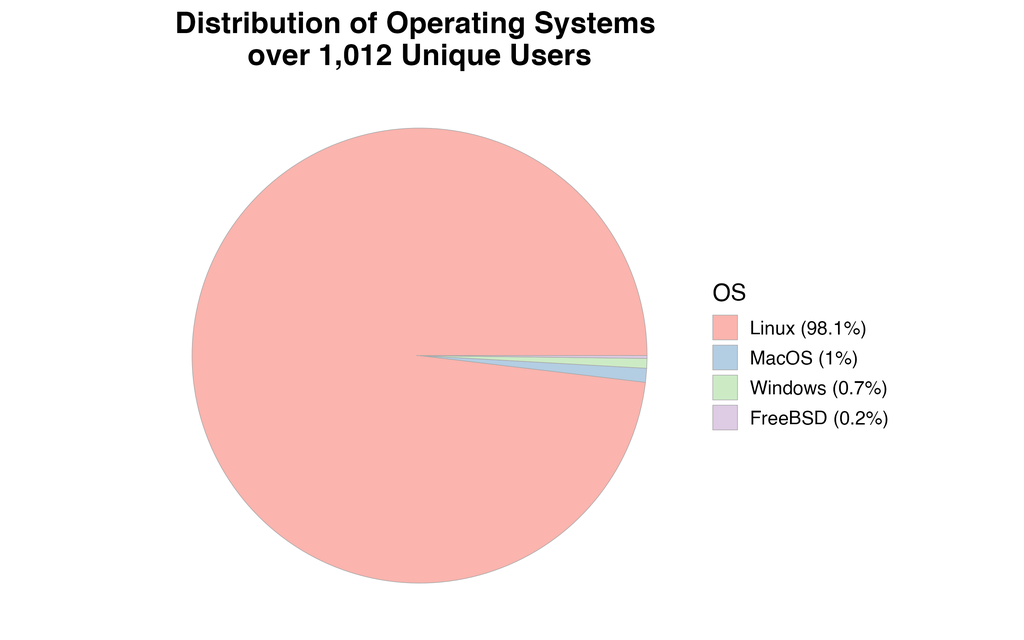

PDF PNG TSV

## New Unique User Statistic

The bar plots on the left display the unique new users. New Unique users means that each IP Adress tracked only appears once in this statistic at the time point of it’s first occurence. The line plot on the right displays the same information as a line instead of bars. The red line on the left plot shows the cumulative sum of the new unique users.

### Bar

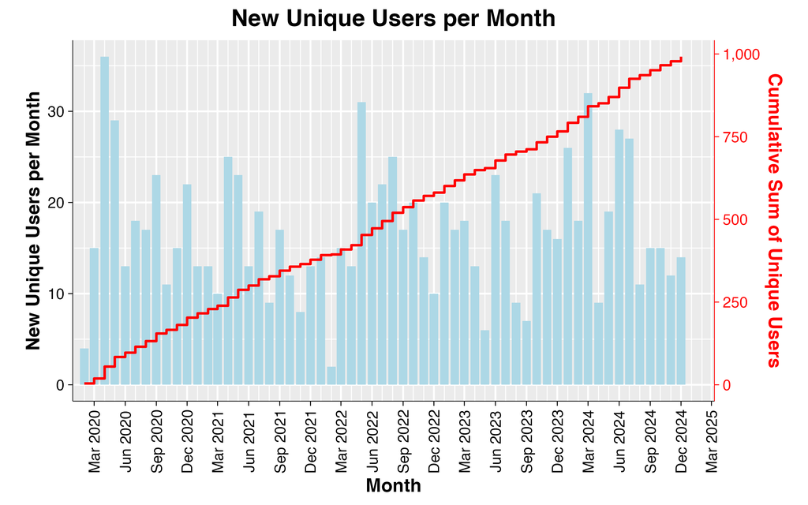

PDF PNG TSV

### Line

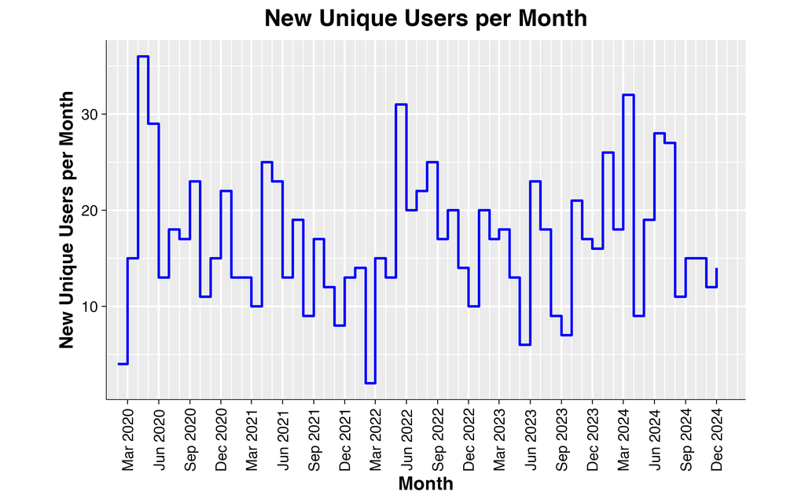

PDF PNG TSV

## Unique User Statistic

### Bar

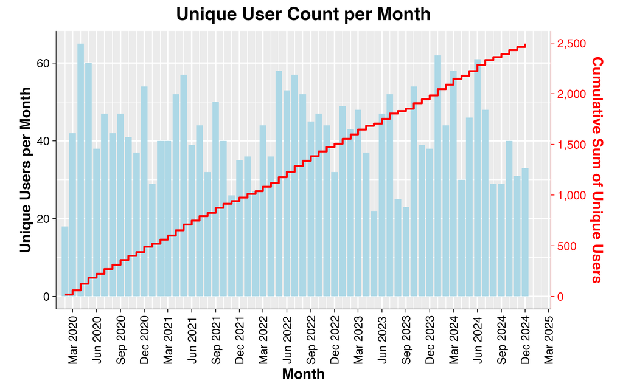

PDF PNG TSV

### Line

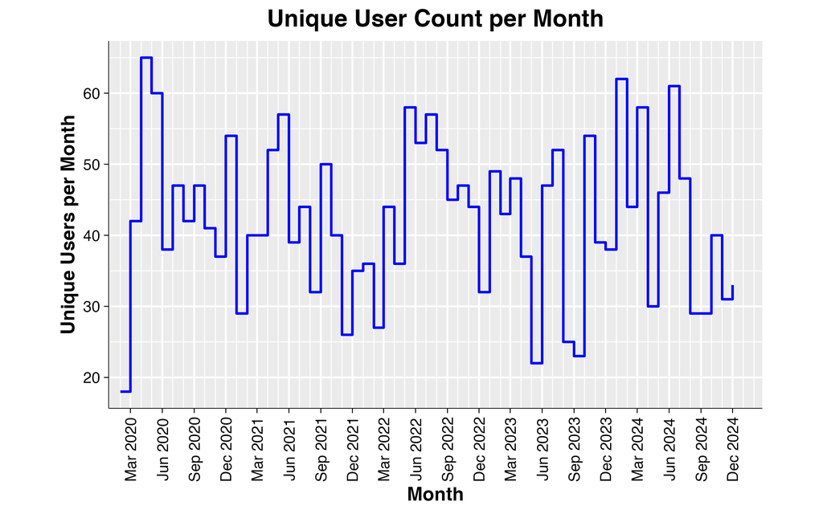

PDF PNG TSV

## Total Calls Statistic

For comparison the following plots show the toal counts of usages (calls) per month, accumulated and as a line plot.

### Bar

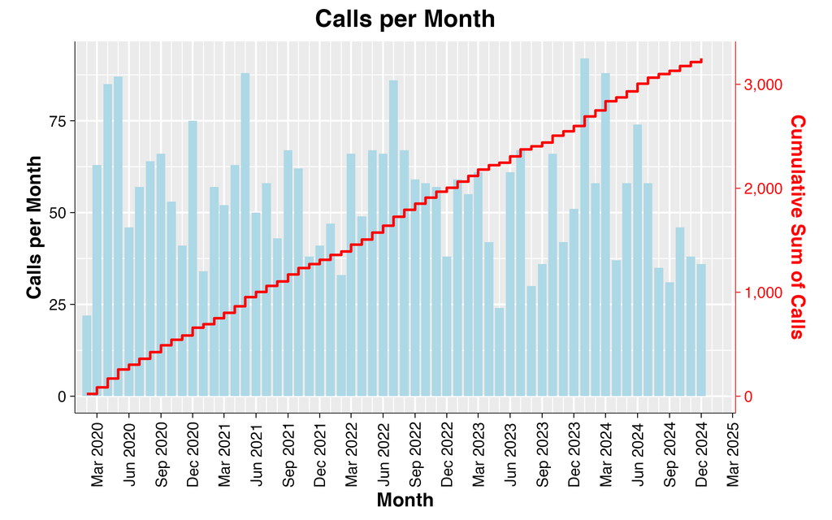

PDF PNG TSV

### Line

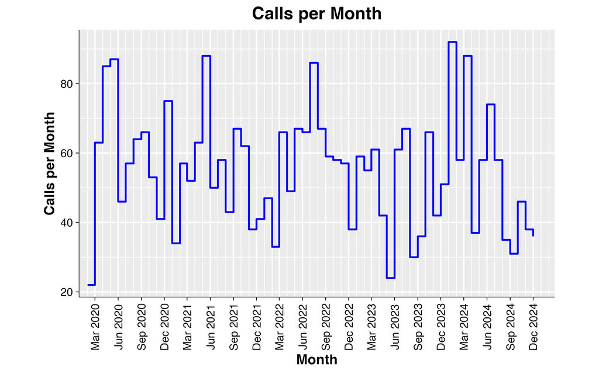

PDF PNG TSV

## Distribution of Countries and Cities

| Application | Countries | Cities | Country with most calls | Calls from Country | City with most calls | Calls from City |
| --- | --- | --- | --- | --- | --- | --- |
| razers3 | 51.0 | 284.0 | United States of America | 847.0 | Ashburn | 174.0 |
| flexbar | 24.0 | 44.0 | United States of America | 44.0 | Columbus | 25.0 |
| GenMap | 19.0 | 38.0 | Japan | 24.0 | Tokyo | 24.0 |
| yara_indexer | 18.0 | 35.0 | Japan | 66.0 | Tokyo | 64.0 |
| yara_mapper | 14.0 | 41.0 | United States of America | 85.0 | Tokyo | 65.0 |
| RLM | 13.0 | 23.0 | United States of America | 15.0 | Tokyo | 7.0 |
| adaptFinder | 11.0 | 22.0 | United States of America | 9.0 | Tempe | 3.0 |
| mason_simulator | 10.0 | 26.0 | United States of America | 19.0 | Shanghai | 3.0 |
| mason_genome | 7.0 | 11.0 | United States of America | 5.0 | Beijing | 2.0 |
| alf | 4.0 | 5.0 | United States of America | 5.0 | North Bergen | 4.0 |
| gustaf_mate_joining | 4.0 | 5.0 | United States of America | 4.0 | North Bergen | 3.0 |
| mason_variator | 4.0 | 9.0 | United States of America | 6.0 | Amsterdam | 1.0 |
| seqan_tcoffee | 4.0 | 6.0 | United States of America | 3.0 | Fontana Liri | 1.0 |
| Indexer | 3.0 | 3.0 | United States of America | 2.0 | North Bergen | 2.0 |
| Penguin_Parade | 3.0 | 3.0 | United States of America | 3.0 | North Bergen | 3.0 |
| Raptor | 3.0 | 6.0 | United States of America | 21.0 | North Bergen | 18.0 |
| Test | 3.0 | 3.0 | Switzerland | 2.0 | Zurich | 2.0 |
| compute_gain | 3.0 | 3.0 | Finland | 1.0 | Amsterdam | 1.0 |
| dfi | 3.0 | 3.0 | United States of America | 2.0 | North Bergen | 2.0 |
| fiona_illumina | 3.0 | 3.0 | Denmark | 1.0 | Amsterdam | 1.0 |
| fx_bam_coverage | 3.0 | 3.0 | Brazil | 1.0 | Franca | 1.0 |
| lambda | 3.0 | 6.0 | United States of America | 5.0 | Honolulu | 2.0 |
| lambda2 | 3.0 | 3.0 | Colombia | 1.0 | Bucaramanga | 1.0 |
| lambda3 | 3.0 | 3.0 | Switzerland | 16.0 | Zurich | 16.0 |
| lambda_indexer | 3.0 | 5.0 | United States of America | 5.0 | Honolulu | 3.0 |
| needle | 3.0 | 4.0 | Spain | 194.0 | Vigo | 194.0 |
| ovgraphbuild | 3.0 | 4.0 | United States of America | 6.0 | Detroit | 5.0 |
| rabema_prepare_sam | 3.0 | 3.0 | Italy | 1.0 | Amsterdam | 1.0 |
| roi_feature_projection | 3.0 | 4.0 | Brazil | 2.0 | Al Mazzunah | 1.0 |
| samcat | 3.0 | 3.0 | Denmark | 1.0 | Frederiksberg | 1.0 |
| stellar | 3.0 | 6.0 | United States of America | 7.0 | North Bergen | 4.0 |
| fiona | 2.0 | 6.0 | United States of America | 6.0 | Charlotte | 2.0 |
| gustaf | 2.0 | 2.0 | Finland | 1.0 | Espoo | 1.0 |
| insegt | 2.0 | 5.0 | United States of America | 5.0 | North Bergen | 2.0 |
| lara | 2.0 | 2.0 | China | 2.0 | Wuhan | 2.0 |
| my_program | 2.0 | 2.0 | Switzerland | 3.0 | North Bergen | 3.0 |
| mygit | 2.0 | 2.0 | Netherlands (Kingdom of the) | 2.0 | Amsterdam | 2.0 |
| pair_align | 2.0 | 2.0 | Indonesia | 1.0 | Mulia | 1.0 |
| rabema_evaluate | 2.0 | 3.0 | United States of America | 2.0 | Chita | 1.0 |
| sak | 2.0 | 2.0 | China | 1.0 | Beijing | 1.0 |
| sam2matrix | 2.0 | 5.0 | United States of America | 3.0 | Columbus | 1.0 |
| slimm | 2.0 | 2.0 | Netherlands (Kingdom of the) | 2.0 | Nijmegen | 2.0 |
| tree_recon | 2.0 | 3.0 | United States of America | 4.0 | North Bergen | 3.0 |
| AnnotateBam | 1.0 | 1.0 | China | 2.0 | Hangzhou | 2.0 |
| Contamination | 1.0 | 1.0 | China | 2.0 | Hangzhou | 2.0 |
| Demultiplexer | 1.0 | 1.0 | Malaysia | 1.0 | Kampung Kadok | 1.0 |
| HmnTrimmer | 1.0 | 1.0 | Hong Kong | 1.0 | Hong Kong | 1.0 |
| Mapper | 1.0 | 1.0 | Switzerland | 1.0 | Zurich | 1.0 |
| MergeBam | 1.0 | 1.0 | China | 2.0 | Hangzhou | 2.0 |
| MinionReadAnalyzer | 1.0 | 1.0 | China | 2.0 | Shanghai | 2.0 |
| Search | 1.0 | 1.0 | Singapore | 1.0 | Singapore | 1.0 |
| bam2roi | 1.0 | 1.0 | United States of America | 1.0 | North Bergen | 1.0 |
| bisar | 1.0 | 1.0 | United States of America | 1.0 | San Francisco | 1.0 |
| casbar | 1.0 | 2.0 | United States of America | 2.0 | Madison | 1.0 |
| corrprofile | 1.0 | 1.0 | United States of America | 1.0 | Columbus | 1.0 |
| count | 1.0 | 1.0 | New Zealand | 1.0 | Christchurch | 1.0 |
| customgenomegenerator | 1.0 | 1.0 | Switzerland | 2.0 | Zurich | 2.0 |
| four2three | 1.0 | 1.0 | United States of America | 1.0 | North Bergen | 1.0 |
| fx_fastq_stats | 1.0 | 2.0 | United States of America | 2.0 | Ashburn | 1.0 |
| ibf_bitscore | 1.0 | 1.0 | Argentina | 1.0 | Salta | 1.0 |
| join | 1.0 | 1.0 | United States of America | 1.0 | North Bergen | 1.0 |
| kgl_phylo | 1.0 | 1.0 | United States of America | 1.0 | Little Rock | 1.0 |
| mason_frag_sequencing | 1.0 | 1.0 | United States of America | 1.0 | North Bergen | 1.0 |
| mason_materializer | 1.0 | 2.0 | United States of America | 2.0 | Bellevue | 1.0 |
| mason_methylation | 1.0 | 1.0 | Korea (the Republic of) | 1.0 | Seongnam | 1.0 |
| mason_splicing | 1.0 | 1.0 | United States of America | 1.0 | North Bergen | 1.0 |
| mhc | 1.0 | 1.0 | Taiwan (Province of China) | 1.0 | Taipei | 1.0 |
| micro_razers | 1.0 | 1.0 | United States of America | 1.0 | North Bergen | 1.0 |
| minions | 1.0 | 1.0 | Switzerland | 16.0 | Zurich | 16.0 |
| pizzly | 1.0 | 1.0 | United States of America | 1.0 | Honolulu | 1.0 |
| rabema_build_gold_standard | 1.0 | 2.0 | United States of America | 2.0 | Cupertino | 1.0 |
| razers | 1.0 | 1.0 | United States of America | 1.0 | North Bergen | 1.0 |
| select | 1.0 | 1.0 | New Zealand | 1.0 | Christchurch | 1.0 |
| singleCellPipe | 1.0 | 1.0 | United States of America | 1.0 | Tampa | 1.0 |
| slimm_build | 1.0 | 1.0 | United States of America | 1.0 | North Bergen | 1.0 |
| snp_store | 1.0 | 3.0 | United States of America | 4.0 | North Bergen | 2.0 |
| st_index_search | 1.0 | 2.0 | United States of America | 3.0 | North Bergen | 2.0 |
| umis_per_barcode | 1.0 | 1.0 | New Zealand | 1.0 | Christchurch | 1.0 |
| valik | 1.0 | 1.0 | United States of America | 2.0 | Atlanta | 2.0 |

TSV

## Daily and Weekly Usage

| Application | Calls | Average per Day | Average per Week |
| --- | --- | --- | --- |
| razers3 | 2147.0 | 1.19344 | 8.3541 |
| yara_mapper | 240.0 | 0.13341 | 0.9339 |
| needle | 199.0 | 0.11062 | 0.7743 |
| yara_indexer | 192.0 | 0.10673 | 0.7471 |
| flexbar | 93.0 | 0.05170 | 0.3619 |
| GenMap | 78.0 | 0.04336 | 0.3035 |
| RLM | 36.0 | 0.02001 | 0.1401 |
| mason_simulator | 31.0 | 0.01723 | 0.1206 |
| adaptFinder | 26.0 | 0.01445 | 0.1012 |
| Raptor | 24.0 | 0.01334 | 0.0934 |
| lambda3 | 19.0 | 0.01056 | 0.0739 |
| minions | 16.0 | 0.00889 | 0.0623 |
| mason_genome | 12.0 | 0.00667 | 0.0467 |
| ovgraphbuild | 12.0 | 0.00667 | 0.0467 |
| mason_variator | 9.0 | 0.00500 | 0.0350 |
| stellar | 9.0 | 0.00500 | 0.0350 |
| alf | 8.0 | 0.00445 | 0.0311 |
| lambda_indexer | 8.0 | 0.00445 | 0.0311 |
| fiona | 7.0 | 0.00389 | 0.0272 |
| gustaf_mate_joining | 7.0 | 0.00389 | 0.0272 |
| lambda | 7.0 | 0.00389 | 0.0272 |
| insegt | 6.0 | 0.00334 | 0.0233 |
| my_program | 6.0 | 0.00334 | 0.0233 |
| seqan_tcoffee | 6.0 | 0.00334 | 0.0233 |
| Penguin_Parade | 5.0 | 0.00278 | 0.0195 |
| sam2matrix | 5.0 | 0.00278 | 0.0195 |
| tree_recon | 5.0 | 0.00278 | 0.0195 |
| Indexer | 4.0 | 0.00222 | 0.0156 |
| Test | 4.0 | 0.00222 | 0.0156 |
| dfi | 4.0 | 0.00222 | 0.0156 |
| mygit | 4.0 | 0.00222 | 0.0156 |
| roi_feature_projection | 4.0 | 0.00222 | 0.0156 |
| snp_store | 4.0 | 0.00222 | 0.0156 |
| compute_gain | 3.0 | 0.00167 | 0.0117 |
| fiona_illumina | 3.0 | 0.00167 | 0.0117 |
| fx_bam_coverage | 3.0 | 0.00167 | 0.0117 |
| lambda2 | 3.0 | 0.00167 | 0.0117 |
| lara | 3.0 | 0.00167 | 0.0117 |
| rabema_evaluate | 3.0 | 0.00167 | 0.0117 |
| rabema_prepare_sam | 3.0 | 0.00167 | 0.0117 |
| samcat | 3.0 | 0.00167 | 0.0117 |
| slimm | 3.0 | 0.00167 | 0.0117 |
| st_index_search | 3.0 | 0.00167 | 0.0117 |
| AnnotateBam | 2.0 | 0.00111 | 0.0078 |
| Contamination | 2.0 | 0.00111 | 0.0078 |
| MergeBam | 2.0 | 0.00111 | 0.0078 |
| MinionReadAnalyzer | 2.0 | 0.00111 | 0.0078 |
| casbar | 2.0 | 0.00111 | 0.0078 |
| customgenomegenerator | 2.0 | 0.00111 | 0.0078 |
| fx_fastq_stats | 2.0 | 0.00111 | 0.0078 |
| gustaf | 2.0 | 0.00111 | 0.0078 |
| mason_materializer | 2.0 | 0.00111 | 0.0078 |
| pair_align | 2.0 | 0.00111 | 0.0078 |
| rabema_build_gold_standard | 2.0 | 0.00111 | 0.0078 |
| sak | 2.0 | 0.00111 | 0.0078 |
| valik | 2.0 | 0.00111 | 0.0078 |
| Demultiplexer | 1.0 | 0.00056 | 0.0039 |
| HmnTrimmer | 1.0 | 0.00056 | 0.0039 |
| Mapper | 1.0 | 0.00056 | 0.0039 |
| Search | 1.0 | 0.00056 | 0.0039 |
| bam2roi | 1.0 | 0.00056 | 0.0039 |
| bisar | 1.0 | 0.00056 | 0.0039 |
| corrprofile | 1.0 | 0.00056 | 0.0039 |
| count | 1.0 | 0.00056 | 0.0039 |
| four2three | 1.0 | 0.00056 | 0.0039 |
| ibf_bitscore | 1.0 | 0.00056 | 0.0039 |
| join | 1.0 | 0.00056 | 0.0039 |
| kgl_phylo | 1.0 | 0.00056 | 0.0039 |
| mason_frag_sequencing | 1.0 | 0.00056 | 0.0039 |
| mason_methylation | 1.0 | 0.00056 | 0.0039 |
| mason_splicing | 1.0 | 0.00056 | 0.0039 |
| mhc | 1.0 | 0.00056 | 0.0039 |
| micro_razers | 1.0 | 0.00056 | 0.0039 |
| pizzly | 1.0 | 0.00056 | 0.0039 |
| razers | 1.0 | 0.00056 | 0.0039 |
| select | 1.0 | 0.00056 | 0.0039 |
| singleCellPipe | 1.0 | 0.00056 | 0.0039 |
| slimm_build | 1.0 | 0.00056 | 0.0039 |
| umis_per_barcode | 1.0 | 0.00056 | 0.0039 |

TSV